# Wrapping up a project

management

A guide to project retrospectives.

At the end of a project or at the close of any significant milestone, phase or quarter in the project, a project wrap-up or retrospective gives an opportunity to celebrate the team’s achievements, get feedback on what can be improved, learn from each other and reflect on overall impact and performance. Here is an approach for individual and team reflection that I’ve used on projects with some success. It is a two part process; an individual reflection on personal and team performance by each team member, followed by a round robin team discussion.

### Individual reflection

Supports individual reflection on your time on the project. It also forces you to structure your thoughts and think through lessons learnt to share with your team. Each team member identifies the following:

- **What went well?** What tasks did you enjoy? What achievements can be celebrated? Think about stakeholder interaction, ways of working, deliverables, project goals, workshops etc.
- **What didn’t go so well?** What challenges did we face? What were the moments when you felt stuck? Why were they frustrating? Were the challenges technical, business-related, communication-related, or politics?
- **What can I take away?** What did you learn from the challenges you faced on this project? How can you improve on the challenge you faced to improve future projects? What were your personal learning goals for this project or sprint?
- *(For Managers) What could I have done better to support and advocate for my team and project goals?*

**Template**

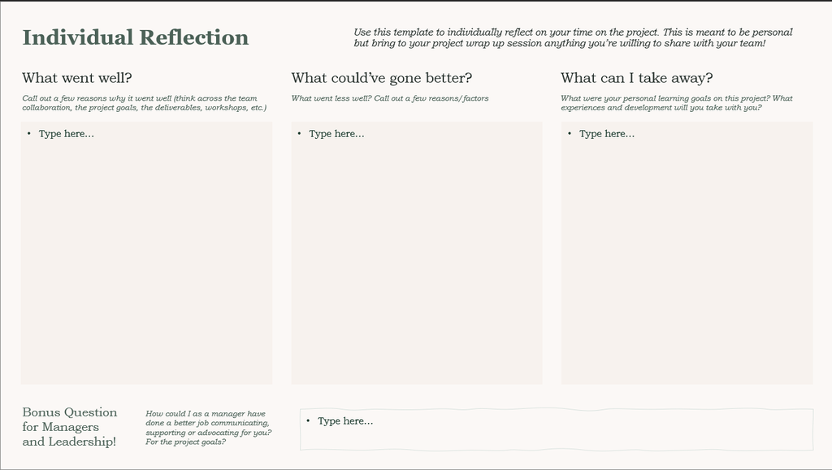

### Team reflection

Share project experiences and reflections as a team, identifying areas for celebration and opportunities for improvement to facilitate team consensus on project impact. Classify experiences along four quadrants in a matrix:

**Template**

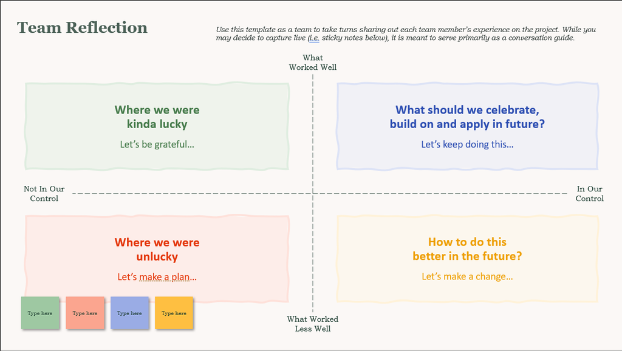

[figure not shown]

### Project Wrap up Meeting

1. Before the meeting
   1. Set up a Project Wrap Up meeting
   2. Clarify purpose, agenda of the meeting
   3. Ask the team to fill out individual reflection template ~15 minutes
2. During the meeting
   1. Clarify purpose and agenda of the meeting
   2. Set the time period under discussion (last sprint, last quarter)
   3. Communicate ground rules ~ 5 minutes
      - Dont take it personally
      - Everyone’s experience is valid
      - Go with an open mind
      - Focus on improvements rather than placing blame
   4. Ask team members to share what went well, what didn’t go well and actions in a rapid round robin ~ 30 minutes
   5. Update team reflection template in real-time
3. After the meeting
   1. After the meeting, send out team reflection document to the team

### Conclusion

Retrospectives take 30-60 minutes and can have a great impact on team performance, growth and motivation. It has personally helped me reflect on the work I’ve done for the past 3-6 months, critically think about my achievements and mistakes I wont repeat on my next project.

*Helpful resources: [Data Science and Agile (What Works, and What Doesn’t) by Eugene Yan](https://eugeneyan.com/writing/what-i-love-about-scrum-for-data-science/), [Altassan Retrospectives](https://www.atlassian.com/team-playbook/plays/retrospective,)*